# simon-5501-12-demo

This code was written by Steve Simon on 2024-10-29 and is placed in the public domain.

This program is split into two parts.

# — Part 1

This section of the program reads data on admissions to an emergency room before, during, and after a full moon. Find more information in the [data dictionary](https://github.com/pmean/data/blob/master/files/full-moon-er-admissions.yaml).

## Datasets

- er: original data from full-moon-er-admissions.txt
- er1: re-ordered factors

## Models

- m1: two-factor ANOVA using aov function

## Load the tidyverse library

```r
library(broom)
library(tidyverse)
```

## Read the data and view a brief summary

```r
er <- read_tsv(
  "../data/full-moon-er-admissions.txt",
  col_types="ccn",
  col_names=TRUE)
names(er) <- tolower(names(er))
glimpse(er)
```

```
Rows: 36
Columns: 3
$ month     <chr> "Aug", "Sep", "Oct", "Nov", "Dec", "Jan", "Feb", "Mar", "Apr…
$ moon      <chr> "Before", "Before", "Before", "Before", "Before", "Before", …
$ admission <dbl> 6.4, 7.1, 6.5, 8.6, 8.1, 10.4, 11.5, 13.8, 15.4, 15.7, 11.7,…
```

#### Comments on the code

This is a tab delimited file. I changed all the variable names to all lowercase. That’s one less thing opportunity for inconsistency errors.

## Reorder the category levels, 1

```r
moon_levels <- c(
    "Before",
    "During",
    "After")


month_levels <- c(
    "Aug", "Sep", "Oct",
    "Nov", "Dec", "Jan",
    "Feb", "Mar", "Apr",
    "May", "Jun", "Jul")

er |>
  mutate(moon=factor(moon, levels=moon_levels)) |>
  mutate(month=factor(month, levels=month_levels)) -> er1
```

#### Comments on the code

If you let R order the categories, it will do it alphabetically. The factor function will place them in a more logical order.

Since the study started in August, it makes sense to order the months starting then. An alphabetical ordering (April, August, December, …, September) makes no sense here. Starting the levels at the first month of the study (August) makes that month the reference category.

There are several ways to think about the proper ordering of the moon factor. One is to list them in the order before, during, and after. This makes the time before a full moon the reference category.

## Draw boxplot of admission versus moon

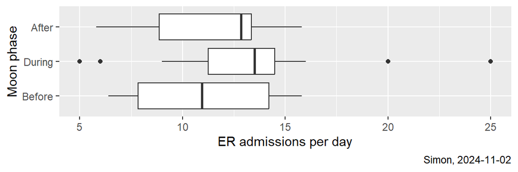

```r
er1 |>
  ggplot() +
    aes(x=admission, y=moon) +
      geom_boxplot() +
      labs(
        x="ER admissions per day",
        y="Moon phase",
        caption="Simon, 2024-11-02")
```

#### Interpretation of the output

Although there are a few outliers, I would not worry too much about the normality assumption. It also looks like heterogeneity would not be too much of a concern.

## Draw scatterplot of admission versus month

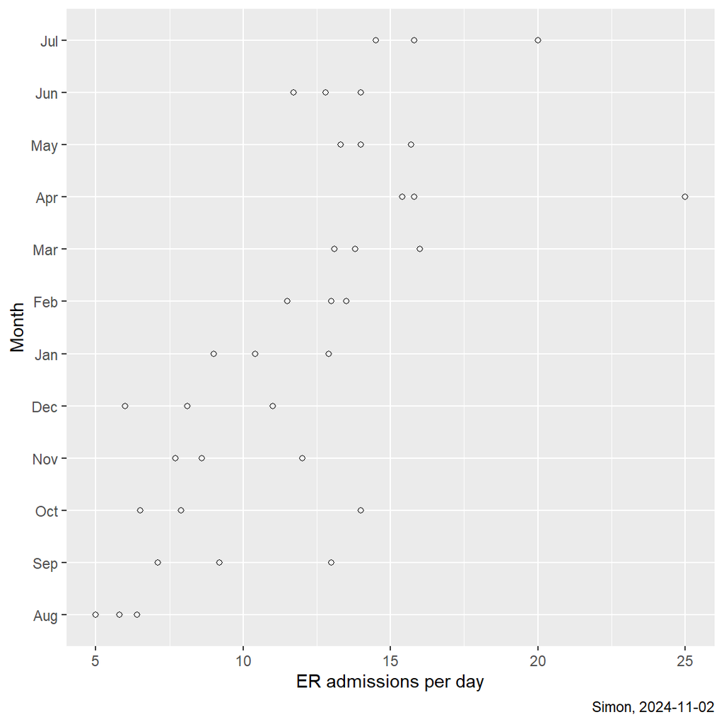

```r
er1 |>
  ggplot() +
  aes(admission, month) +
  geom_point(shape="circle open") +
    labs(
        x="ER admissions per day",
        y="Month",
        caption="Simon, 2024-11-02")
```

#### Comment on the code

Normally, I would use a boxplot here. But in this dataset, there are only three data points per month. A boxplot is a graphical display of five number summary (min, 25th percentle, 50th percentile, 75th percentile, and maximum) and makes little sense with three observations.

#### Interpretation of the output

Although there are some unusual patterns here, keep in mind that there are only three observations per month. It looks like later months, shown near the top of the graph, are larger than earlier months, shown near the bottom of the graph.

## Calculate average ER admissions versus moon

```r
er1 |>
  group_by(moon) |>
  summarize(
    admission_mn=mean(admission),
    admission_sd=sd(admission),
    n=n())
```

```
# A tibble: 3 × 4
  moon   admission_mn admission_sd     n
  <fct>         <dbl>        <dbl> <int>
1 Before         10.9         3.62    12
2 During         13.4         5.50    12
3 After          11.5         3.11    12
```

#### Interpretation of the output

There is a slightly higher average admission rate and slightly more variation during a full moon.

## Calculate average ER admissions versus month

```r
er1 |>
  group_by(month) |>
  summarize(
    admission_mn=mean(admission),
    admission_sd=sd(admission),
    n=n())
```

```
# A tibble: 12 × 4
   month admission_mn admission_sd     n
   <fct>        <dbl>        <dbl> <int>
 1 Aug           5.73        0.702     3
 2 Sep           9.77        2.99      3
 3 Oct           9.47        3.99      3
 4 Nov           9.43        2.27      3
 5 Dec           8.37        2.51      3
 6 Jan          10.8         1.98      3
 7 Feb          12.7         1.04      3
 8 Mar          14.3         1.51      3
 9 Apr          18.7         5.43      3
10 May          14.3         1.23      3
11 Jun          12.8         1.15      3
12 Jul          16.8         2.87      3
```

#### Interpretation of the output

Er admissions are trending upward over time and there is some evidence of heterogeneity. Again, treat this with caution as there are only three observations per month.

## Analysis of variance

```r
m1 <- aov(admission ~ moon + month, data=er1)
tidy(m1)
```

```
# A tibble: 3 × 6
  term         df sumsq meansq statistic    p.value
  <chr>     <dbl> <dbl>  <dbl>     <dbl>      <dbl>
1 moon          2  41.5  20.8       3.57  0.0453
2 month        11 456.   41.4       7.13  0.0000508
3 Residuals    22 128.    5.81     NA    NA
```

#### Interpretation of the output

There is a borderline, but statistically significant difference in average admission rates during different phases of the moon. There is a statistically significant difference in average admission rates between some of the months.

## Tukey post hoc test

```r
TukeyHSD(m1)
```

```
  Tukey multiple comparisons of means
    95% family-wise confidence level

Fit: aov(formula = admission ~ moon + month, data = er1)

$moon
                    diff         lwr       upr     p adj
During-Before  2.5000000  0.02803652 4.9719635 0.0471250
After-Before   0.5416667 -1.93029682 3.0136302 0.8473143
After-During  -1.9583333 -4.43029682 0.5136302 0.1382640

$month
               diff          lwr       upr     p adj
Sep-Aug  4.03333333  -3.12570650 11.192373 0.6590633
Oct-Aug  3.73333333  -3.42570650 10.892373 0.7493888
Nov-Aug  3.70000000  -3.45903984 10.859040 0.7588977
Dec-Aug  2.63333333  -4.52570650  9.792373 0.9640031
Jan-Aug  5.03333333  -2.12570650 12.192373 0.3576853
Feb-Aug  6.93333333  -0.22570650 14.092373 0.0633963
Mar-Aug  8.56666667   1.40762683 15.725707 0.0104953
Apr-Aug 13.00000000   5.84096016 20.159040 0.0000631
May-Aug  8.60000000   1.44096016 15.759040 0.0101025
Jun-Aug  7.10000000  -0.05903984 14.259040 0.0532271
Jul-Aug 11.03333333   3.87429350 18.192373 0.0005980
Oct-Sep -0.30000000  -7.45903984  6.859040 1.0000000
Nov-Sep -0.33333333  -7.49237317  6.825707 1.0000000
Dec-Sep -1.40000000  -8.55903984  5.759040 0.9998138
Jan-Sep  1.00000000  -6.15903984  8.159040 0.9999933
Feb-Sep  2.90000000  -4.25903984 10.059040 0.9329667
Mar-Sep  4.53333333  -2.62570650 11.692373 0.5019803
Apr-Sep  8.96666667   1.80762683 16.125707 0.0066267
May-Sep  4.56666667  -2.59237317 11.725707 0.4917380
Jun-Sep  3.06666667  -4.09237317 10.225707 0.9066121
Jul-Sep  7.00000000  -0.15903984 14.159040 0.0591328
Nov-Oct -0.03333333  -7.19237317  7.125707 1.0000000
Dec-Oct -1.10000000  -8.25903984  6.059040 0.9999825
Jan-Oct  1.30000000  -5.85903984  8.459040 0.9999087
Feb-Oct  3.20000000  -3.95903984 10.359040 0.8815456
Mar-Oct  4.83333333  -2.32570650 11.992373 0.4126699
Apr-Oct  9.26666667   2.10762683 16.425707 0.0046821
```

[output cut: 24 more lines]

```
Mar-Feb  1.63333333  -5.52570650  8.792373 0.9992191
Apr-Feb  6.06666667  -1.09237317 13.225707 0.1496863
May-Feb  1.66666667  -5.49237317  8.825707 0.9990631
Jun-Feb  0.16666667  -6.99237317  7.325707 1.0000000
Jul-Feb  4.10000000  -3.05903984 11.259040 0.6381994
Apr-Mar  4.43333333  -2.72570650 11.592373 0.5330487
May-Mar  0.03333333  -7.12570650  7.192373 1.0000000
Jun-Mar -1.46666667  -8.62570650  5.692373 0.9997108
Jul-Mar  2.46666667  -4.69237317  9.625707 0.9771591
May-Apr -4.40000000 -11.55903984  2.759040 0.5434969
Jun-Apr -5.90000000 -13.05903984  1.259040 0.1745228
Jul-Apr -1.96666667  -9.12570650  5.192373 0.9960667
Jun-May -1.50000000  -8.65903984  5.659040 0.9996431
Jul-May  2.43333333  -4.72570650  9.592373 0.9792886
Jul-Jun  3.93333333  -3.22570650 11.092373 0.6899464
```

#### Interpretation of the output

The interpretation here is tricky. Start by ignoring the Tukey post hoc intervals for months. There are just too many intervals and the focus is not on the months anyway.

There is the temptation to state that the average number of admissions jumps from the time before a full moon to the time during a full moon and that it falls back again to about the same level after a full moon. There is a statistically significant difference between the “before” and “during” groups, but it is borderline. The lower limit is just barely above zero. There is not a statistically significant difference between the “during” and “after” groups, but again the results are borderline. The upper limit is just barely above zero.

The only really definitive finding is that there is no statistically significant difference between the “before” and “after” groups.

# — Part 2

This section of the program reads data on fruit fly longevity. Find more information in the [data dictionary](https://github.com/pmean/data/blob/master/files/fruitfly.yaml).

## Datasets

- fly: original data from ../data/fruitfly.txt
- fly1: subset appropriate for two factor ANOVA

## Models

- m2: two-factor ANOVA using aov function
- m3: two-factor ANOVA using lm function

## List the variable names

```r
vlist <- c(
  "id",
  "partners",
  "type",
  "longevity",
  "thorax",
  "sleep")
```

#### Comments on the code

When a dataset does not have variables on the first line, you need to specify them in the code.

## Read the data and view a brief summary

```r
fly <- read_fwf(
  "../data/fruitfly.txt",
  col_types="nnnnnn",
  fwf_widths(
    widths=c(2, 2, 2, 3, 5, 3),
    col_names=vlist))
glimpse(fly)
```

```
Rows: 125
Columns: 6
$ id        <dbl> 1, 2, 3, 4, 5, 6, 7, 8, 9, 10, 11, 12, 13, 14, 15, 16, 17, 1…
$ partners  <dbl> 8, 8, 8, 8, 8, 8, 8, 8, 8, 8, 8, 8, 8, 8, 8, 8, 8, 8, 8, 8, …
$ type      <dbl> 0, 0, 0, 0, 0, 0, 0, 0, 0, 0, 0, 0, 0, 0, 0, 0, 0, 0, 0, 0, …
$ longevity <dbl> 35, 37, 49, 46, 63, 39, 46, 56, 63, 65, 56, 65, 70, 63, 65, …
$ thorax    <dbl> 0.64, 0.68, 0.68, 0.72, 0.72, 0.76, 0.76, 0.76, 0.76, 0.76, …
$ sleep     <dbl> 22, 9, 49, 1, 23, 83, 23, 15, 9, 81, 12, 15, 37, 24, 26, 17,…
```

#### Comments on the code

The fruitfly dataset has a fixed width format (fwf). You need to specify the columns that each variable uses.

Notice that the two categorical variables, partners and type, are actually numbers rather than strings. To avoid having R treat these variables as if they were continuous, use the factor function in some of the code below.

## Create a subset of fruitfly dataset

```r
fly |>
  filter(type != 9) -> fly1
```

#### Comments on the code

If you exclude the pure control group (No females), you can analyze the two factors, partners and type individually. Partners has two category levels, 1 for when one female was included in the cage and 8 for when eight females were included in the cage. Type also has two category levels, 0 for pregnant female fly/flies and 1 for virgin fly/flies. A male fly will not mate with a pregnant females, so you can think of this as a second level of controls. The two factors are crossed, meaning that every possible combination of partners and type has outcomes measured.

## Draw boxplot of longevity by partners and type

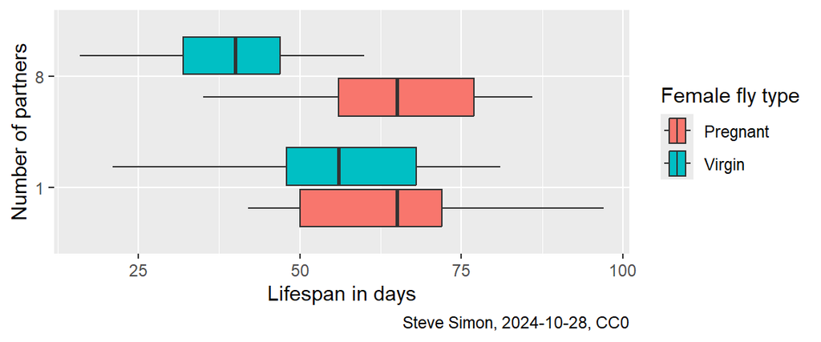

```r
fly1 |>
  ggplot() +
    aes(
        x=longevity,
        y=factor(partners),
        fill=factor(type)) +
  geom_boxplot() +
  labs(
    x="Lifespan in days",
    y="Number of partners",
    fill="Female fly type",
    caption="Steve Simon, 2024-10-28, CC0") +
  scale_fill_discrete(labels=c("Pregnant", "Virgin"))
```

#### Interpretation of the output

The lifespans tend to be quite a bit shorter in cages with 8 virgin females. There are no problems with the homogeneity and normality assumptions.

## Calculate average longevity by partners and type

```r
fly1 |>
  group_by(type, partners) |>
  summarize(
    longevity_mn=mean(longevity),
    longevity_sd=sd(longevity),
    n=n()) -> fly_means
fly_means
```

```
# A tibble: 4 × 5
# Groups:   type [2]
   type partners longevity_mn longevity_sd     n
  <dbl>    <dbl>        <dbl>        <dbl> <int>
1     0        1         64.8         15.7    25
2     0        8         63.4         14.5    25
3     1        1         56.8         14.9    25
4     1        8         38.7         12.1    25
```

#### Interpretation of the output

The means show the same pattern as noted above. The standard deviations are all roughly the same.

## Draw line graph

```
`geom_line()`: Each group consists of only one observation.
ℹ Do you need to adjust the group aesthetic?
```

[figure not shown]

```r
fly_means |>
  ggplot() +
  aes(
    x=factor(partners),
    y=longevity_mn,
    # group=factor(type),
    color=factor(type)) +
    geom_line(linewidth=2) +
    expand_limits(y=range(fly1$longevity)) +
    labs(
        x="Number of partners",
        y="Lifespan in days",
        color="Female fly type",
        caption="Steve Simon, 2024-10-28, CC0") +
  scale_color_discrete(labels=c("Pregnant", "Virgin"))
```

#### Interpretation of the output

Male fruitflies do appear to have shorter average lifespans when sharing a cage with virgin females compared to pregnant females, but this effect is far stronger when the number of female fruitflies is eight rather than one.

## Analysis of variance including the interaction

```r
m2 <- aov(longevity ~ factor(partners)*factor(type), data=fly1)
anova(m2)
```

```
Analysis of Variance Table

Response: longevity
                              Df  Sum Sq Mean Sq F value    Pr(>F)
factor(partners)               1  2371.7  2371.7  11.489  0.001017 **
factor(type)                   1  6674.9  6674.9  32.335 1.397e-07 ***
factor(partners):factor(type)  1  1722.3  1722.3   8.343  0.004785 **
Residuals                     96 19817.4   206.4
---
Signif. codes:  0 '***' 0.001 '**' 0.01 '*' 0.05 '.' 0.1 ' ' 1
```

#### Interpretation of the output

There is a statistically significant interaction between the number of female partners and the type of partners (pregnant or virgin). When you have an interaction, you do not normally interpret the individual categorical predictors.

## Using lm, 1

```r
m3 <- lm(longevity ~ factor(partners)*factor(type), data=fly1)
anova(m3)
```

```
Analysis of Variance Table

Response: longevity
                              Df  Sum Sq Mean Sq F value    Pr(>F)
factor(partners)               1  2371.7  2371.7  11.489  0.001017 **
factor(type)                   1  6674.9  6674.9  32.335 1.397e-07 ***
factor(partners):factor(type)  1  1722.3  1722.3   8.343  0.004785 **
Residuals                     96 19817.4   206.4
---
Signif. codes:  0 '***' 0.001 '**' 0.01 '*' 0.05 '.' 0.1 ' ' 1
```

#### Interpretation of the output

The analysis of variance table is identical when using lm instead of aov.

## Using lm, 2

```r
tidy(m3)
```

```
# A tibble: 4 × 5
  term                            estimate std.error statistic  p.value
  <chr>                              <dbl>     <dbl>     <dbl>    <dbl>
1 (Intercept)                        64.8       2.87    22.6   3.87e-40
2 factor(partners)8                  -1.44      4.06    -0.354 7.24e- 1
3 factor(type)1                      -8.04      4.06    -1.98  5.07e- 2
4 factor(partners)8:factor(type)1   -16.6       5.75    -2.89  4.79e- 3
```

#### Interpretation of the output

The lifespan of fruitflies in cages with 8 virgin females is 17 days shorter than what you would expect. If the effect of type and partners were independent, you’d expect to see a 9.4 (= 8.0 + 1.4) day decline on average. The interaction shows that this cage is actually 16.6 days worse than that on average.

## Using lm, 3

```r
b <- coef(m2)
fly_means |>
  mutate(b0=b[1]) |>
  mutate(b1=b[2]) |>
  mutate(b2=b[3]) |>
  mutate(b3=b[4]) |>
    select(-longevity_sd, -n) -> fly_coefficients
fly_coefficients[1, 5:7] <- 0
fly_coefficients[2, 6:7] <- 0
fly_coefficients[3, c(5,7)] <- 0
fly_coefficients
```

```
# A tibble: 4 × 7
# Groups:   type [2]
   type partners longevity_mn    b0    b1    b2    b3
  <dbl>    <dbl>        <dbl> <dbl> <dbl> <dbl> <dbl>
1     0        1         64.8  64.8  0     0      0
2     0        8         63.4  64.8 -1.44  0      0
3     1        1         56.8  64.8  0    -8.04   0
4     1        8         38.7  64.8 -1.44 -8.04 -16.6
```

#### Comments on the code

The coef function takes the intercept and slopes from a linear regression model and stores them in a vector. The mutate command adds the individual intercept and slopes to separate columns. Finally, place zeros in places where the various slopes are not needed.

#### Interpretation of the output

This table is not needed for the data analysis, but is included to illustrate how the regression coefficients are computed in a two factor analysis of variance with an interaction.

The intercept is the estimated average with both categories each to the “zero” or reference level. In this case, the average lifespan of flies in a cage with one pregnant female.

The first slope coefficient (b1) represents the estimated average difference in lifespan between eight pregnant females and one pregnant females.

The second slope coefficient (b2) represents the estimated average difference in lifespan between one pregnant females and one virgin female.

The third slope coefficient (b3) represents the interaction. It is a measure of how much shorter the average lifespan is with eight virgin females above and beyond the individual impact of eight versus one and virgin versus pregnant.